# HW.Clean.5

Logan Hardy

2/28/2022

25 points (20 for this assignment, 5 for being on time)

# Import (2 points)

Import the executive comp dataset and the Stolen_Vehicles_2012_Salt_Lake_City dataset with readr. Import all date time columns in a date-time format. Strings should be factors.

```r
exec_comp_main <- read_csv("../Data/exec_comp_main.csv", col_types = cols(Formation.yr = col_datetime(format = "%Y"))) %>% mutate_if(is.character, as.factor)

Stolen_Vehicles_2012_Salt_Lake_City <- read_csv("../Data/Stolen_Vehicles_2012_Salt_Lake_City.csv", col_types = cols(`REPORT DATE` = col_datetime(format = "%m/%d/%Y %I:%M:%S %p"), `OCC DATE` = col_datetime(format = "%m/%d/%Y %I:%M:%S %p"))) %>% mutate_if(is.character, as.factor)
```

# Outliers

## Finding outliers with summary (3 points)

*In the console* run a summary of the exec_comp_main dataset.

Q: Name at least 3 columns that you think have outliers and describe why you think so.  
A: Revenue - mean is significantly larger than median and 3rd quartile (indicating its right skewed and probably has outliers) Expenses - mean is significantly larger than median and 3rd quartile (indicating its right skewed and probably has outliers) Liabilities - mean is significantly larger than median and 3rd quartile (indicating its right skewed and probably has outliers) Assets - mean is significantly larger than median and 3rd quartile (indicating its right skewed and probably has outliers) Reportable.comp - Max is significantly further away from mean/median than min Health.and.benefits - Mean is significantly larger than median and 3rd quartile (indicating its right skewed and probably has outliers)

## Finding outliers with visualizations (2 points)

Make a histogram and boxplot of the Liabilities column of the exec_comp_main dataset.

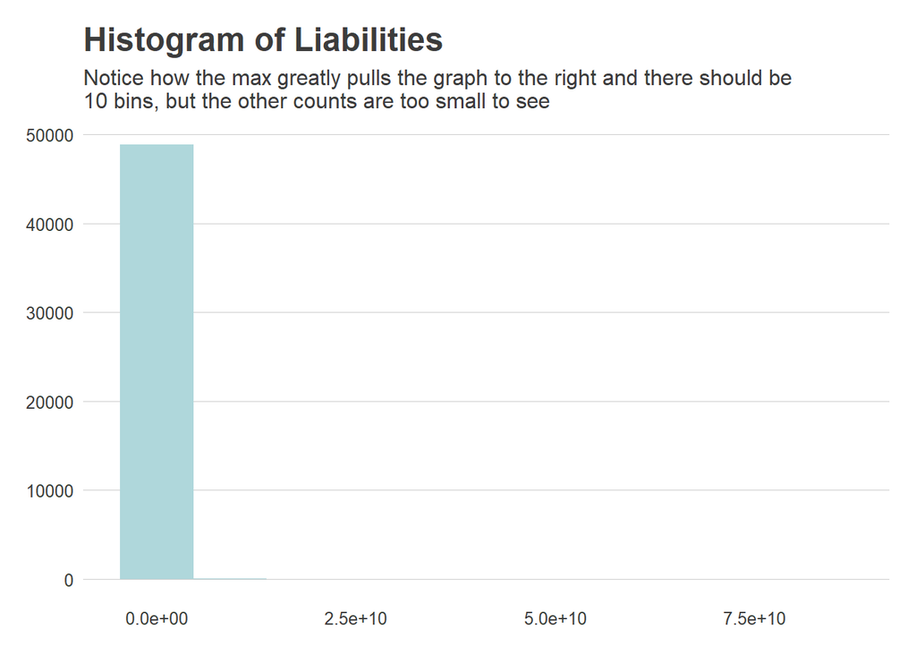

```r
theme_new <-  theme_fivethirtyeight(base_size=12#,base_family="Open Sans"
                                    ) %+replace% theme(panel.grid.major.y = element_line(colour = "grey80", size = 0.25),  panel.grid.major.x = element_blank(), panel.background = element_rect(fill = "white"), plot.background = element_rect(fill = "white"), legend.background = element_rect(fill = "white"))

exec_comp_main %>% ggplot(aes(x = Liabilities)) + geom_histogram(fill = "#afd7db", bins = 10) +
        labs(title = "Histogram of Liabilities",
            subtitle = "Notice how the max greatly pulls the graph to the right and there should be \n10 bins, but the other counts are too small to see",
            y = "Count",
            x = "Liabilities") +
        theme_new #+ theme(axis.title = element_text(size = 10, color = "grey40"))
```

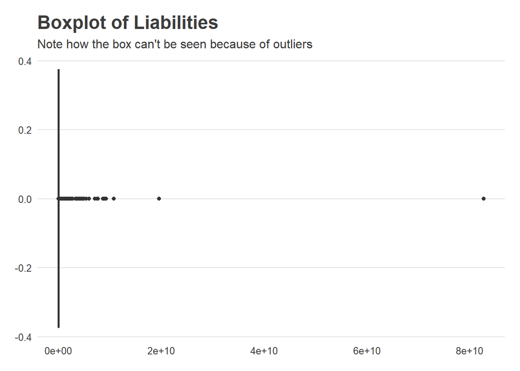

```r
exec_comp_main %>% ggplot(aes(x = Liabilities)) +
        geom_boxplot(fill = "#afd7db") +
        labs(title = "Boxplot of Liabilities",
            subtitle = "Note how the box can't be seen because of outliers",
            x = "Liabilities") +
        theme_new #+ theme(axis.title = element_text(size = 10, color = "grey40"))
```

Q: Based on these graphs, why or why not do you think there are outliers in this variable?  
A: Based on these graphs, I think that there are outliers because neither graph fully shows.

## Using the Boxplot function to find outliers (3 points)

Use the boxplot function to find the index of outliers in the Expenses column. Output the head() of a subset of just rows with outliers in that variable. Then output the head() of a subset that has a new column that says whether there are outliers in that expenses column.

```r
boxplot_outliers <- boxplot.stats(exec_comp_main$Expenses)$out
outlier_indexes <- which(exec_comp_main$Expenses %in% c(boxplot_outliers))

# dataset of just outliers.
exec_comp_main[outlier_indexes, ] %>% head()
```

```
## # A tibble: 6 x 16
##   Title  Trustee.or.dire~ Officer Key.employee Highest.compens~ Revenue Expenses
##   <fct>  <lgl>            <lgl>   <lgl>        <lgl>              <dbl>    <dbl>
## 1 direc~ FALSE            FALSE   FALSE        TRUE              4.85e7   5.18e7
## 2 direc~ FALSE            FALSE   FALSE        TRUE              4.85e7   5.18e7
## 3 direc~ TRUE             TRUE    FALSE        FALSE             4.85e7   5.18e7
## 4 direc~ FALSE            FALSE   FALSE        TRUE              4.85e7   5.18e7
## 5 direc~ TRUE             TRUE    FALSE        FALSE             1.99e9   1.63e9
## 6 direc~ FALSE            FALSE   TRUE         FALSE             1.99e9   1.63e9
## # ... with 9 more variables: Liabilities <dbl>, Assets <dbl>,
## #   Formation.yr <dttm>, State <fct>, City <fct>, Reportable.comp <dbl>,
## #   Health.and.benefits <dbl>, Base <dbl>, Other.comp.all <dbl>
```

```r
# subset that has a new column that says whether there are outliers in that expenses column.
exec_comp_main %>%
  mutate(ExpensesOutlier = ifelse(Expenses %in% c(boxplot_outliers), TRUE, FALSE)) %>% head()
```

```
## # A tibble: 6 x 17
##   Title  Trustee.or.dire~ Officer Key.employee Highest.compens~ Revenue Expenses
##   <fct>  <lgl>            <lgl>   <lgl>        <lgl>              <dbl>    <dbl>
## 1 board~ TRUE             FALSE   FALSE        FALSE             1.79e6   500749
## 2 direc~ FALSE            TRUE    FALSE        FALSE             1.59e5   147841
## 3 direc~ FALSE            TRUE    FALSE        FALSE             1.59e5   147841
## 4 direc~ FALSE            FALSE   FALSE        TRUE              4.85e7 51811094
## 5 direc~ FALSE            FALSE   FALSE        TRUE              4.85e7 51811094
## 6 direc~ TRUE             TRUE    FALSE        FALSE             4.85e7 51811094
## # ... with 10 more variables: Liabilities <dbl>, Assets <dbl>,
## #   Formation.yr <dttm>, State <fct>, City <fct>, Reportable.comp <dbl>,
## #   Health.and.benefits <dbl>, Base <dbl>, Other.comp.all <dbl>,
## #   ExpensesOutlier <lgl>
```

Q: How many rows have an outlier in the expenses column according to the boxplot function?  
A: 7,021

## Using percentile to replace outliers with NAs (3 points)

Make a copy of the exec_comp_main dataset. Create a cut off of 95% and 5% for outliers. Replace all outliers in the Assets colum with NA.

```r
exec_comp_main_NAs <- exec_comp_main

lower_bound <- quantile(exec_comp_main_NAs$Assets, 0.05, na.rm = TRUE)
upper_bound <- quantile(exec_comp_main_NAs$Assets, 0.95, na.rm = TRUE)

# This provides the indexes of outliers
outlier_indexes <- which(exec_comp_main_NAs$Assets < lower_bound | exec_comp_main_NAs$Assets > upper_bound)

# And makes a dataset with just outliers
exec_comp_main_NAs[outlier_indexes, "Assets"] <- NA

# Count NAs
#sum(is.na(exec_comp_main$Assets))
#sum(is.na(exec_comp_main_NAs$Assets))
```

Q: How many NAs were in that column before you replaced outliers?  
A: 0

Q: How many NAs are in the dataset copy with replaced NAs?  
A: 4969

# Date-Time

## Creating new date-time columns (4 points)

All the functions and formatting we did with date times can be used within a mutate function to create new date-time columns.

Create a new copy of the stolen vehicle dataset and overwrite it to include 4 new columns:

1. a column called REPORTING_QUARTER that has the year and quarter when the incident was reported
2. a column called REPORTING_LAPSE that has the difference between the time the incident happened (OCC DATE) and when it was reported in days (hint: if you nest each column in as.Date they will output the difference in days not seconds.)
3. a column called INCIDENT_WEEKDAY that has the weekday (written out, like “Sunday”) when the incident happened
4. a column called INCIDENT_WEEK that has a numerical value for which week in the year the incident happened. (Sunday should be the first day of that week.)

Then output the head() of the dataset.

```r
library(zoo)
Stolen_Vehicles_2012_Salt_Lake_City_COPY <- Stolen_Vehicles_2012_Salt_Lake_City

Stolen_Vehicles_2012_Salt_Lake_City_COPY <- Stolen_Vehicles_2012_Salt_Lake_City_COPY %>% mutate(REPORTING_QUARTER <- as.yearqtr(`REPORT DATE`, "%m/%d/%Y %I:%M:%S %p"), REPORTING_LAPSE <- (as.Date(`REPORT DATE`) - as.Date(`OCC DATE`)), INCIDENT_WEEKDAY <- format(`OCC DATE`, "%A"), INCIDENT_WEEK <- format(`OCC DATE`, "%U"))

Stolen_Vehicles_2012_Salt_Lake_City_COPY %>% head()
```

```
## # A tibble: 6 x 12
##   CASE   `OFFENSE CODE` `OFFENSE DESCR~` `REPORT DATE`       `OCC DATE`
##   <fct>  <fct>          <fct>            <dttm>              <dttm>
## 1 SL201~ 2499-13        STOLEN VEHICLE   2012-08-14 02:38:00 2012-08-14 01:30:00
## 2 SL201~ 2404-64        STOLEN VEHICLE   2012-10-12 17:49:00 2012-10-12 10:00:00
## 3 SL201~ 2499-13        STOLEN VEHICLE   2012-01-07 16:24:00 2012-01-07 16:24:00
## 4 SL201~ 2499-15        STOLEN VEHICLE   2012-12-01 16:52:00 2012-12-01 16:52:00
## 5 SL201~ 2499-13        STOLEN VEHICLE   2012-10-23 16:50:00 2012-10-23 16:50:00
## 6 SL201~ 2499-14        STOLEN VEHICLE   2012-08-13 12:53:00 2012-08-13 12:53:00
## # ... with 7 more variables: `DAY OF WEEK` <dbl>, LOCATION <fct>,
## #   `Location 1` <fct>, `REPORTING_QUARTER <- ...` <yearqtr>,
## #   `REPORTING_LAPSE <- ...` <drtn>,
## #   `INCIDENT_WEEKDAY <- format(\`OCC DATE\`, "%A")` <chr>,
## #   `INCIDENT_WEEK <- format(\`OCC DATE\`, "%U")` <chr>
```

## Other date-time practice (3 points)

```r
# Turn the following string into a POSIXct format
as.POSIXct("June 14, 22 (Tuesday) 10:34 pm", format="%B %d, %y (%A) %I:%M %p")
```

```
## [1] "2022-06-14 22:34:00 MDT"
```

```r
# Turn the following string into a POSIXct format (assume it is in correct Mountain Daylight Time), then convert it to the time zone of Central Europe (CET).
date1 <- as.POSIXct("Feb 20 2022 13:55:22", format="%b %d %Y %H:%M:%S")
with_tz(date1, tzone = "CET")
```

```
## [1] "2022-02-20 21:55:22 CET"
```

```r
# Turn the following string into a date format then extract the month fully spelled out.
date2 <- as.Date("2022-11-06", format="%Y-%m-%d")
format(date2, "%B")
```

```
## [1] "November"
```

–End–

# Optional feedback:

How hard was this assignment? Was it: too hard, too easy, or just right?

ANSWER: Just Right

Approximately how long did this assignment take you?

ANSWER: 3 hours